# Case Study - Parameter Tuning using Spam Data

# 1 Code

Use the button to the right to expand the code for reading in the emails and creating the dataset that will be used to model.

```r
#setwd(dirname(rstudioapi::getActiveDocumentContext()$path))

# set directory path
spamPath = "../Data"

# get the directory names
dirNames = list.files(path = paste(spamPath, "messages", sep = .Platform$file.sep))

# create a list of all spam email file names
fullDirNames = paste(spamPath, "messages", dirNames, sep = .Platform$file.sep)
fileNames = list.files(fullDirNames[1], full.names = TRUE)

# split the message into header/body based on the first blank row in the email
splitMessage = function(msg) {
  # look for the first blank line
  splitPoint = match("", msg)
  # header are rows before the first blank line
  header = msg[1:(splitPoint-1)]
  # body are rows after the first blank line
  body = msg[ -(1:splitPoint) ]
  return(list(header = header, body = body))
}

# get boundary positions for attachment
getBoundary = function(header) {
  boundaryIdx = grep("boundary=", header)
  boundary = gsub('"', "", header[boundaryIdx])
  gsub(".*boundary= *([^;]*);?.*", "\\1", boundary)
}

# process the header into usable arguments
processHeader = function(header) {
  # modify the first line to create a key:value pair
  header[1] = sub("^From", "Top-From:", header[1])

  # reads data in the format key: value and accounts for continuation on subsequent lines
  headerMat = read.dcf(textConnection(header), all = TRUE)
  # convert to character vector with key as the name for each value
  headerVec = unlist(headerMat)

  dupKeys = sapply(headerMat, function(x) length(unlist(x)))
  names(headerVec) = rep(colnames(headerMat), dupKeys)

  return(headerVec)
  }

# process the attachment
processAttach = function(body, contentType){

  n = length(body)
  boundary = getBoundary(contentType)

  bString = paste("--", boundary, sep = "")
  bStringLocs = which(bString == body)
  eString = paste("--", boundary, "--", sep = "")
  eStringLoc = which(eString == body)

  if (length(eStringLoc) == 0) eStringLoc = n
  if (length(bStringLocs) <= 1) {
    attachLocs = NULL
    msgLastLine = n
    if (length(bStringLocs) == 0) bStringLocs = 0
  } else {
    attachLocs = c(bStringLocs[ -1 ],  eStringLoc)
    msgLastLine = bStringLocs[2] - 1
  }

  msg = body[ (bStringLocs[1] + 1) : msgLastLine]
  if ( eStringLoc < n )
    msg = c(msg, body[ (eStringLoc + 1) : n ])

  if ( !is.null(attachLocs) ) {
    attachLens = diff(attachLocs, lag = 1)
    attachTypes = mapply(function(begL, endL) {
      CTloc = grep("^[Cc]ontent-[Tt]ype", body[ (begL + 1) : (endL - 1)])
      if ( length(CTloc) == 0 ) {
        MIMEType = NA
      } else {
        CTval = body[ begL + CTloc[1] ]
        CTval = gsub('"', "", CTval )
        MIMEType = sub(" *[Cc]ontent-[Tt]ype: *([^;]*);?.*", "\\1", CTval)
      }
      return(MIMEType)
    }, attachLocs[-length(attachLocs)], attachLocs[-1])
  }

  if (is.null(attachLocs)) return(list(body = msg, attachDF = NULL) )
  return(list(body = msg,
              attachDF = data.frame(aLen = attachLens,
                                    aType = unlist(attachTypes),
                                    stringsAsFactors = FALSE)))

  }

readEmail = function(dirName) {
  # retrieve the names of files in directory
  fileNames = list.files(dirName, full.names = TRUE)
  # drop files that are not email
  notEmail = grep("cmds$", fileNames)
  if ( length(notEmail) > 0) fileNames = fileNames[ - notEmail ]

  # read all files in the directory
  lapply(fileNames, readLines, encoding = "latin1")
}


# process all emails, including headers and attachments
processAllEmail = function(dirName, isSpam = FALSE)
{
  # read all files in the directory
  messages = readEmail(dirName)
  fileNames = names(messages)
  n = length(messages)

  # split header from body
  eSplit = lapply(messages, splitMessage)
  rm(messages)

  # process header as named character vector
  headerList = lapply(eSplit, function(msg)
    processHeader(msg$header))

  # extract content-type key
  contentTypes = sapply(headerList, function(header)
    header["Content-Type"])

  # extract the body
  bodyList = lapply(eSplit, function(msg) msg$body)
  rm(eSplit)

  # which email have attachments
  hasAttach = grep("^ *multi", tolower(contentTypes))

  # get summary stats for attachments and the shorter body
  attList = mapply(processAttach, bodyList[hasAttach],
                   contentTypes[hasAttach], SIMPLIFY = FALSE)

  bodyList[hasAttach] = lapply(attList, function(attEl)
    attEl$body)

  attachInfo = vector("list", length = n )
  attachInfo[ hasAttach ] = lapply(attList,
                                   function(attEl) attEl$attachDF)

  # prepare return structure
  emailList = mapply(function(header, body, attach, isSpam) {
    list(isSpam = isSpam, header = header,
         body = body, attach = attach)
  },
  headerList, bodyList, attachInfo,
  rep(isSpam, n), SIMPLIFY = FALSE )
  names(emailList) = fileNames

  invisible(emailList)
}

# apply the over-arching function to all emails
emailStruct = mapply(processAllEmail, fullDirNames, isSpam = rep( c(FALSE, TRUE), 3:2))
emailStruct = unlist(emailStruct, recursive = FALSE)

# save the processed email file
save(emailStruct, file="emailXX.rda")

# create a derived function that allows the code to remain virtually unchanged when adding/removing functions
createDerivedDF = function(email = emailStruct, operations = funcList, verbose = FALSE) {
  els = lapply(names(operations), function(id) {
    if(verbose) print(id)
    e = operations[[id]]
    v = if(is.function(e))
      sapply(email, e)
    else
      sapply(email, function(msg) eval(e))
    v
    })

  df = as.data.frame(els)
  names(df) = names(operations)
  invisible(df)
  }

# create list of functions that can be applied to emails
funcList = list(
  isSpam =
    expression(msg$isSpam)
  ,

  # is the message a response from an earlier message
  isRe =
    function(msg) {
      # Can have a Fwd: Re:  ... but we are not looking for this here.
      # We may want to look at In-Reply-To field.
      "Subject" %in% names(msg$header) &&
        length(grep("^[ \t]*Re:", msg$header[["Subject"]])) > 0
    }
  ,
  numLines =
    function(msg) length(msg$body)
  ,
  bodyCharCt =
    function(msg)
      sum(nchar(msg$body))
  ,
  underscore =
    function(msg) {
      if(!"Reply-To" %in% names(msg$header))
        return(FALSE)
```

```r
      txt <- msg$header[["Reply-To"]]
      length(grep("_", txt)) > 0  &&
        length(grep("[0-9A-Za-z]+", txt)) > 0
    }
  ,
  subExcCt =
    function(msg) {
      x = msg$header["Subject"]
      if(length(x) == 0 || sum(nchar(x)) == 0 || is.na(x))
        return(NA)

      sum(nchar(gsub("[^!]","", x)))
    }
  ,
  subQuesCt =
    function(msg) {
      x = msg$header["Subject"]
      if(length(x) == 0 || sum(nchar(x)) == 0 || is.na(x))
        return(NA)

      sum(nchar(gsub("[^?]","", x)))
    }
  ,
  numAtt =
    function(msg) {
      if (is.null(msg$attach)) return(0)
      else nrow(msg$attach)
    }

  ,
  priority =
    function(msg) {
      ans <- FALSE
      # Look for names X-Priority, Priority, X-Msmail-Priority
      # Look for high any where in the value
      ind = grep("priority", tolower(names(msg$header)))
      if (length(ind) > 0)  {
        ans <- length(grep("high", tolower(msg$header[ind]))) >0
      }
      ans
    }
  ,
  numRec =
    function(msg) {
      # unique or not.
      els = getMessageRecipients(msg$header)

      if(length(els) == 0)
        return(NA)

      # Split each line by ","  and in each of these elements, look for
      # the @ sign. This handles
      tmp = sapply(strsplit(els, ","), function(x) grep("@", x))
      sum(sapply(tmp, length))
    }
  ,
  perCaps =
    function(msg)
    {
      body = paste(msg$body, collapse = "")

      # Return NA if the body of the message is "empty"
      if(length(body) == 0 || nchar(body) == 0) return(NA)

      # Eliminate non-alpha characters and empty lines
      body = gsub("[^[:alpha:]]", "", body)
      els = unlist(strsplit(body, ""))
      ctCap = sum(els %in% LETTERS)
      100 * ctCap / length(els)
    }
  ,
  isInReplyTo =
    function(msg)
    {
      "In-Reply-To" %in% names(msg$header)
    }
  ,
  sortedRec =
    function(msg)
    {
      ids = getMessageRecipients(msg$header)
      all(sort(ids) == ids)
    }
  ,
  subPunc =
    function(msg)
    {
      if("Subject" %in% names(msg$header)) {
        el = gsub("['/.:@-]", "", msg$header["Subject"])
        length(grep("[A-Za-z][[:punct:]]+[A-Za-z]", el)) > 0
      }
      else
        FALSE
    },
  hour =
    function(msg)
    {
      date = msg$header["Date"]
      if ( is.null(date) ) return(NA)
      # Need to handle that there may be only one digit in the hour
      locate = regexpr("[0-2]?[0-9]:[0-5][0-9]:[0-5][0-9]", date)

      if (locate < 0)
        locate = regexpr("[0-2]?[0-9]:[0-5][0-9]", date)
      if (locate < 0) return(NA)

      hour = substring(date, locate, locate+1)
      hour = as.numeric(gsub(":", "", hour))

      locate = regexpr("PM", date)
      if (locate > 0) hour = hour + 12

      locate = regexpr("[+-][0-2][0-9]00", date)
      if (locate < 0) offset = 0
      else offset = as.numeric(substring(date, locate, locate + 2))
      (hour - offset) %% 24
    }
  ,
  multipartText =
    function(msg)
    {
      if (is.null(msg$attach)) return(FALSE)
      numAtt = nrow(msg$attach)

      types =
        length(grep("(html|plain|text)", msg$attach$aType)) > (numAtt/2)
    }
  ,
  hasImages =
    function(msg)
    {
      if (is.null(msg$attach)) return(FALSE)

      length(grep("^ *image", tolower(msg$attach$aType))) > 0
    }
  ,
  isPGPsigned =
    function(msg)
    {
      if (is.null(msg$attach)) return(FALSE)

      length(grep("pgp", tolower(msg$attach$aType))) > 0
    },
  perHTML =
    function(msg)
    {
      if(! ("Content-Type" %in% names(msg$header))) return(0)

      el = tolower(msg$header["Content-Type"])
      if (length(grep("html", el)) == 0) return(0)

      els = gsub("[[:space:]]", "", msg$body)
      totchar = sum(nchar(els))
      totplain = sum(nchar(gsub("<[^<]+>", "", els )))
      100 * (totchar - totplain)/totchar
    },
  subSpamWords =
    function(msg)
    {
      if("Subject" %in% names(msg$header))
        length(grep(paste(SpamCheckWords, collapse = "|"),
                    tolower(msg$header["Subject"]))) > 0
      else
        NA
    }
  ,
  subBlanks =
    function(msg)
    {
      if("Subject" %in% names(msg$header)) {
        x = msg$header["Subject"]
        # should we count blank subject line as 0 or 1 or NA?
        if (nchar(x) == 1) return(0)
        else 100 *(1 - (nchar(gsub("[[:blank:]]", "", x))/nchar(x)))
      } else NA
    }
  ,
  noHost =
    function(msg)
    {
      # Or use partial matching.
      idx = pmatch("Message-", names(msg$header))

      if(is.na(idx)) return(NA)

      tmp = msg$header[idx]
      return(length(grep(".*@[^[:space:]]+", tmp)) ==  0)
    }
  ,
  numEnd =
    function(msg)
    {
      # If we just do a grep("[0-9]@",  )
      # we get matches on messages that have a From something like
      # " \"marty66@aol.com\" <synjan@ecis.com>"
      # and the marty66 is the "user's name" not the login
      # So we can be more precise if we want.
      x = names(msg$header)
      if ( !( "From" %in% x) ) return(NA)
      login = gsub("^.*<", "", msg$header["From"])
      if ( is.null(login) )
        login = gsub("^.*<", "", msg$header["X-From"])
      if ( is.null(login) ) return(NA)
      login = strsplit(login, "@")[[1]][1]
      length(grep("[0-9]+$", login)) > 0
    },

  # identifies if all alpha characters in the subject line are upper case
  isYelling =
    function(msg)
    {
      if ( "Subject" %in% names(msg$header) ) {
        el = gsub("[^[:alpha:]]", "", msg$header["Subject"])
        if (nchar(el) > 0) nchar(gsub("[A-Z]", "", el)) < 1
        else FALSE
      }
      else
        NA
    },
  forwards =
    function(msg)
    {
      x = msg$body
      if(length(x) == 0 || sum(nchar(x)) == 0)
        return(NA)

      ans = length(grep("^[[:space:]]*>", x))
      100 * ans / length(x)
    },
  isOrigMsg =
    function(msg)
    {
      x = msg$body
      if(length(x) == 0) return(NA)

      length(grep("^[^[:alpha:]]*original[^[:alpha:]]+message[^[:alpha:]]*$",
                  tolower(x) ) ) > 0
    },
  isDear =
    function(msg)
    {
      x = msg$body
      if(length(x) == 0) return(NA)
```

```r
      length(grep("^[[:blank:]]*dear +(sir|madam)\\>",
                  tolower(x))) > 0
    },
  isWrote =
    function(msg)
    {
      x = msg$body
      if(length(x) == 0) return(NA)

      length(grep("(wrote|schrieb|ecrit|escribe):", tolower(x) )) > 0
    },
  avgWordLen =
    function(msg)
    {
      txt = paste(msg$body, collapse = " ")
      if(length(txt) == 0 || sum(nchar(txt)) == 0) return(0)

      txt = gsub("[^[:alpha:]]", " ", txt)
      words = unlist(strsplit(txt, "[[:blank:]]+"))
      wordLens = nchar(words)
      mean(wordLens[ wordLens > 0 ])
    }
  ,
  numDlr =
    function(msg)
    {
      x = paste(msg$body, collapse = "")
      if(length(x) == 0 || sum(nchar(x)) == 0)
        return(NA)

      nchar(gsub("[^$]","", x))
    }
)

# spam words
SpamCheckWords = c("viagra", "pounds", "free", "weight", "guarantee", "million", "dollars", "credit", "risk", "prescription", "generic", "drug",
                   "financial", "save", "dollar", "erotic", "million", "barrister", "beneficiary", "easy", "money back", "money", "credit card")


getMessageRecipients = function(header) {
  c(if("To" %in% names(header))  header[["To"]] else character(0),
    if("Cc" %in% names(header))  header[["Cc"]] else character(0),
    if("Bcc" %in% names(header)) header[["Bcc"]] else character(0)
    )
  }

# add in additional derived variables
emailDF = createDerivedDF(emailStruct)
save(emailDF, file="emailDFknit.rda")
```

Use the button to the right to expand the code for recursive partitioning using `caret` with `method=rpart` from R.

```r
### recursive partitioning ###
library(rpart)
library(caret)

# Ok so first of all our data is in T/F 'factors'.  We need to change it to
# numbers.  And as it turns out, there are quite a few NANs as well.  Let's set
# those to zero.
setupRnum = function(data) {
    logicalVars = which(sapply(data, is.logical))
    facVars = lapply(data[, logicalVars], function(x) {
        x = as.numeric(x)
    })
    cbind(facVars, data[, -logicalVars])
}

emailDFnum = setupRnum(emailDF)

emailDFnum[is.na(emailDFnum)] <- 0


# Because our authors prefer Type I/II errors, but the cool kids know that
# precision/recall/F1 is where its at, while the default of caret is accuracy and
# kappa.  To get us all on the same page, I create a function that returns the
# metrics we want.  However, rather than re-invent the wheel, I just install a
# package.  I am not sure if it had Type I/II errors so those I made my self.

library(MLmetrics)
f1 <- function(data, lev = NULL, model = NULL) {
    f1_val <- F1_Score(y_pred = data$pred, y_true = data$obs, positive = lev[1])
    acc <- Accuracy(y_pred = data$pred, y_true = data$obs)
    p <- Precision(y_pred = data$pred, y_true = data$obs, positive = lev[1])
    r <- Recall(y_pred = data$pred, y_true = data$obs, positive = lev[1])
    fp <- sum(data$pred == 0 & data$obs == 1)/length(data$pred)

    fn <- sum(data$pred == 1 & data$obs == 0)/length(data$pred)
    c(prec = p, F1 = f1_val, rec = r, Type_I_err = fp, Type_II_err = fn)
}

library(naivebayes)
library(e1071)
library(rpart)

### rpart with defaults ###
train_control <- trainControl(method = "cv", number = 5, savePredictions = "final",
    summaryFunction = f1)
set.seed(1234)
model_rpart_defaults <- caret::train(as.factor(isSpam) ~ ., data = emailDFnum, trControl = train_control,
    method = "rpart", na.action = na.omit)

# create the dataset used to loop through different values of minsplit and
# maxdepth
control_grid <- expand.grid(minsplit = seq(5, 25, 1), maxdepth = seq(15, 30, 1))

# create the grid used inside caret::train to grid search on cp
cart_grid <- expand.grid(cp = seq(from = 0, to = 0.1, by = 0.001))

# train function for 5-fold cross validation
train_control <- trainControl(method = "cv", number = 5, savePredictions = "final",
    summaryFunction = f1)

# loop to tune cp, minsplit and maxdepth
for (i in 1:nrow(control_grid)) {
    set.seed(1234)
    model_rpart <- caret::train(as.factor(isSpam) ~ ., data = emailDFnum, trControl = train_control,
        method = "rpart", control = rpart.control(minsplit = control_grid$minsplit[i],
            maxdepth = control_grid$maxdepth[i]), tuneGrid = cart_grid, na.action = na.omit)

    # identify which cp parameter for the loop was the best
    results = as.data.frame(model_rpart$results)
    results$minsplit = control_grid$minsplit[i]
    results$maxdepth = control_grid$maxdepth[i]

    if (i != 1) {
        final_result <- rbind(final_result, results)
    } else {
        final_result <- results
    }

    # print(paste0(round(i/nrow(control_grid),4)*100,'% complete',sep=''))
}
save(final_result, file = "final_result_knit.rda")
# identify the winning model's parameters
results_tuned = final_result[which(final_result$prec == max(final_result$prec)),
    ]

# rerun the model with the winning parameters to enable tree plotting
set.seed(1234)
model_rpart_tuned <- caret::train(as.factor(isSpam) ~ ., data = emailDFnum, trControl = train_control,
    method = "rpart", control = rpart.control(minsplit = results_tuned$minsplit,
        maxdepth = results_tuned$maxdepth), tuneGrid = cart_grid, na.action = na.omit)
```

# 2 Introduction

Many machine learning packages come with convenient features, including useful default parameters for many algorithms. While the default parameters are often good, they can be tailored to the specific problem being analyzed. In this case study, we will optimize the `rpart` decision tree algorithm to classify Spam messages from the SpamAssassin corpus. We will perform a grid search across multiple parameters to minimize the error on our dataset. We will also show visualizations to show how our model metrics improve over different values of these parameters.

We sourced the data from the [Data Science in R website](http://rdatasciencecases.org/), but the corpus is also available at the [SpamAssassin website](https://spamassassin.apache.org/downloads.cgi?update=202001292230)

# 3 Question

Question 19: Consider the other parameters that can be used to control the recursive partitioning process. Read the documentation for them in the `rpart.control` documentation. Also, carry out an Internet search for more information on how to tweak the `rpart` tuning parameters. Experiment with values for these parameters. Do the trees that result make sense with your understanding of how the parameters are used? Can you improve the prediction using them?

# 4 Methods

## 4.1 Dataset

For this problem, we will be using the Spam Assassin Corpus which provides emails that can be used to train spam filters. A spam filter tries to judge whether or not an email is spam based on the contents and characteristics of an email. This corpus contains over nine thousand emails, pre-identified as spam or not-spam. There are five directories of messages: 3 folders for not spam and 2 for spam. Each folder contains full email messages including their header, body, and attachments. The header contains information about the recipients as well as other meta-data about the email. Content-Type, for instance, will help us identify if the message has an attachment. This information is typically in a “key: value” format which will be useful for parsing the information. The body contains the actual message as well as any attachments. We will run code to separate these elements and then create features that might be useful for identification of spam vs. not spam.

## 4.2 Dataset Preparation

Our main goals in preparing each message is to separate the header from the body, while also dealing with any attachments present. We will primarily use certain identifiable aspects of the email in the classification model, but first we need to get the emails into a form where we can derive features from them. There are several functions that aid in this process:

`splitMessage` is a function to assist in splitting the header from the body. It looks for the first blank line which is the boundary the two main parts of the email. It uses this index to assign each to their own object then returns them as a list.

`getBoundary` reads the header to determine the boundary that separates any attachments from the body. It uses regular expressions to search the header and determine the boundary.

`processHeader` is used to extract the “key: value” pairs from the header for later use.

`processAttach` separates out the attachment from the body with the help of the `getBoundary` function. It returns the body and some details about the attachment as a list.

`readEmail` this function reads the messages into R from their locations on the hard drive.

`processAllEmail` finally this function uses the functions above to separate each email message into its major components so we can derive features for classification from them.

## 4.3 Feature Creation

`createDerivedDF` uses a list of functions to derive features for classification. This holder function allows us to easily add and remove functions for creating features without having to readjust our code each time.

# 5 Modeling

## 5.1 CART

For our models, we use the `caret` package, which contains many models available for training using its `train` function. The model we will use to predict whether an email is spam or not-spam is CART (Classification and Regression Trees). The CART algorithm can be visualized as a branching tree with leaves or “nodes” representing the algorithm’s predictions and the branches are calculated splits based on features in the model’s feature space, which, in our problem, different features of emails, as described in the Dataset Preparation section. The algorithm repeatedly splits each feature to find the split which results in the greatest information gain. We give a simple example of one possible CART below.

`Figure 1` shows the resulting CART tree for the spam data, using `maxdepth=2`. In this model, the feature `perCaps` was determined to be the best initial split, or root node, of the data between non-spam (0) and spam (1). `perCaps < 13` checks the email message for whether the percentage of capital letters in the email is less than 13%. If it is, then it goes to the left node. Else, it goes to the right node. * Left node - `perHTML < 3.9`: In addition to having less than 13% capitalized letters, if the message characters consist of less than 3.9% HTML tags, then we classify the message as non-spam. Otherwise, we classify the message as spam. * Right node - `numLines < 9.5`: In addition to having greater than or equal to 13% capitalized letters, if the message has less than 9.5 lines, then we classify the message as non-spam. Otherwise, we classify the message as spam.

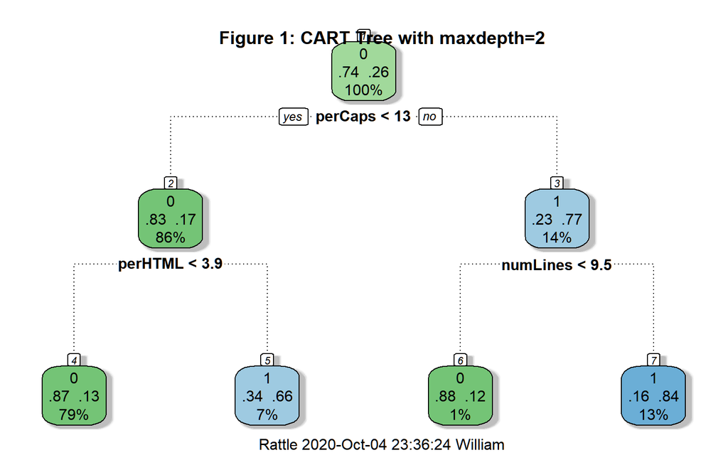

```r
# This is a basic example of a CART with maxdepth=2

set.seed(123)
model_rpart_example <- caret::train(as.factor(isSpam) ~ ., data = emailDFnum, trControl = train_control,
    method = "rpart", control = rpart.control(maxdepth = 2), tuneGrid = cart_grid,
    na.action = na.omit)

# Let us visualize the tree
fancyRpartPlot(model_rpart_example$finalModel, main = "Figure 1: CART Tree with maxdepth=2")
```

We use the `rpart` package and `rpart` method in `caret` to implement CART in this case study.

## 5.2 Parameter Tuning

We can potentially improve upon the model above by tuning the parameters of the model. We took three different parameters–`cp`, `minsplit`, and `maxdepth`–and generated different CART models for each combination of unique values those parameters could take (see `Table 1`).

*Table 1. Parameters of `rpart::rpart.control` and `caret::train` and how they were tuned.*

[output not shown]

There are certain parameters we did not tune as explained in `Table 2` below.

*Table 2. Parameters of `rpart::rpart.control` that we did not explicitly tune.*

[output not shown]

## 5.3 Evaluation Metric

Several evaluation metrics can be used to evaluate performance for a classification algorithm:

- Accuracy - ratio of correctly classified observations to the total observations
- Precision - ratio of correctly predicted spam emails to the total predicted spam emails
- Recall - ratio of correctly predicted spam emails to the total number of actual spam emails
- F1 - weighted average of precision and recall that looks at both false positives and false negatives
- Type I Errors - incorrect identification of an email as spam
- Type II Errors - incorrect identification of an email as not spam

There are benefits and downsides to the various evaluation metrics listed above. Accuracy is easy to understand, but it treats false positives (incorrectly identifying an email as spam) and false negatives (failing to identify an email as spam) equally. For spam, we assume that people would prefer to get the occasional spam email instead of potentially not seeing an important email because it is misclassified as spam. Therefore, our primary objective is to maximize the precision of spam.

# 6 Results

The winning model with the highest precision used the following parameter values: `cp` = 0, `minsplit` = 6, and `maxdepth` = 29. The resulting precision is 96.75%. We compared this to the model using the default values for parameters: `cp` = 0.07 (`cp` was tuned by default as part of `rpart` in `caret::train`), `minsplit` = 20, and `maxdepth` = 30. The resulting precision for the default model was 86.84%. Tuning parameters increased precision from 86.84% to 96.75%.

`Figure 2` below shows the CART tree for the model using default values for the control parameters. The first split on the tree is `perCaps < 13`. The second split on the tree in `perHTML < 3.9`.

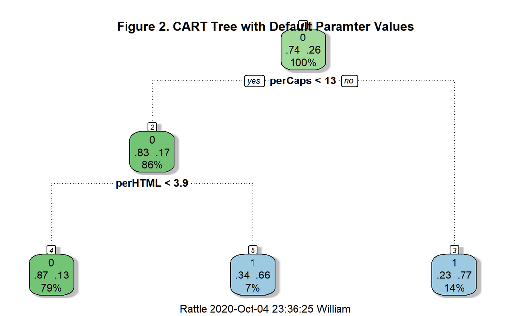

```r
# tree with defaults
fancyRpartPlot(model_rpart_defaults$finalModel, main = "Figure 2. CART Tree with Default Paramter Values")
```

The CART tree for the winning model, `Figure 3`, is shown below. We display this plot only to show the difference in complexity and the increase in `maxdepth`. The `maxdepth` makes this tree not easy to visualize.

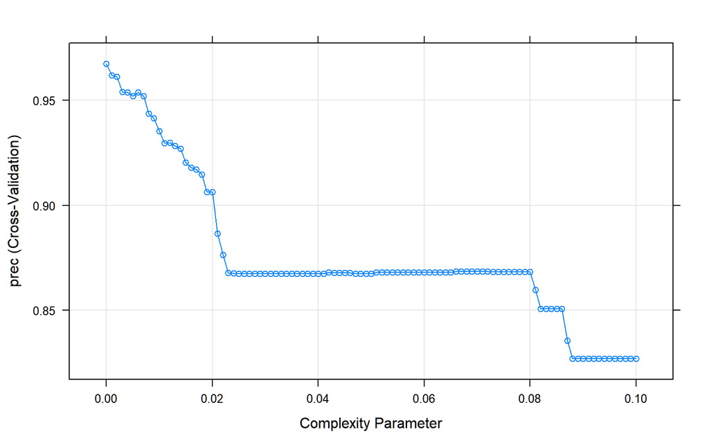

```r
# model_rpart_tuned
plot(model_rpart_tuned)
```

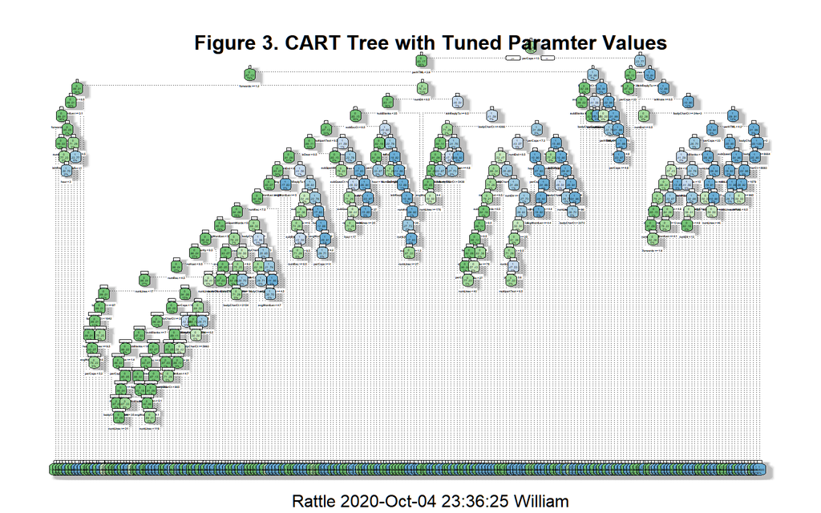

```r
fancyRpartPlot(model_rpart_tuned$finalModel, main = "Figure 3. CART Tree with Tuned Paramter Values")
```

The output below shows the text output for the winning model that corresponds to the tree in `Figure 3`.

```r
model_rpart_tuned$finalModel
```

```
n= 9348

node), split, n, loss, yval, (yprob)
      * denotes terminal node

        1) root 9348 2397 0 (0.743581515 0.256418485)
          2) perCaps< 12.86122 8038 1391 0 (0.826947002 0.173052998)
            4) perHTML< 3.926441 7401  970 0 (0.868936630 0.131063370)
              8) forwards>=1.240008 3369   22 0 (0.993469872 0.006530128)
               16) isDear< 0.5 3367   20 0 (0.994059994 0.005940006)
                 32) avgWordLen>=3.059306 3365   18 0 (0.994650817 0.005349183)
                   64) forwards>=5.81474 3029    1 0 (0.999669858 0.000330142) *
                   65) forwards< 5.81474 336   17 0 (0.949404762 0.050595238)
                    130) perCaps< 9.477678 301    7 0 (0.976744186 0.023255814)
                      260) numDlr< 1.5 270    0 0 (1.000000000 0.000000000) *
                      261) numDlr>=1.5 31    7 0 (0.774193548 0.225806452)
                        522) isInReplyTo>=0.5 21    0 0 (1.000000000 0.000000000) *
                        523) isInReplyTo< 0.5 10    3 1 (0.300000000 0.700000000)
                         1046) hour< 3 3    0 0 (1.000000000 0.000000000) *
                         1047) hour>=3 7    0 1 (0.000000000 1.000000000) *
                    131) perCaps>=9.477678 35   10 0 (0.714285714 0.285714286)
                      262) avgWordLen>=4.464674 22    0 0 (1.000000000 0.000000000) *
                      263) avgWordLen< 4.464674 13    3 1 (0.230769231 0.769230769)
                        526) hour>=16.5 3    0 0 (1.000000000 0.000000000) *
                        527) hour< 16.5 10    0 1 (0.000000000 1.000000000) *
                 33) avgWordLen< 3.059306 2    0 1 (0.000000000 1.000000000) *
               17) isDear>=0.5 2    0 1 (0.000000000 1.000000000) *
              9) forwards< 1.240008 4032  948 0 (0.764880952 0.235119048)
               18) numDlr< 0.5 3340  575 0 (0.827844311 0.172155689)
                 36) subBlanks< 24.79624 3260  495 0 (0.848159509 0.151840491)
                   72) subExcCt< 0.5 3091  394 0 (0.872533161 0.127466839)
                    144) multipartText< 0.5 2953  312 0 (0.894344734 0.105655266)
                      288) isDear< 0.5 2915  274 0 (0.906003431 0.093996569)
                        576) numEnd< 0.5 2795  207 0 (0.925939177 0.074060823)
                         1152) isYelling< 0.5 2765  182 0 (0.934177215 0.065822785)
                           2304) avgWordLen>=2.76982 2752  169 0 (0.938590116 0.061409884)
                             4608) numRec< 7.5 2744  161 0 (0.941326531 0.058673469)
                               9216) subSpamWords< 0.5 2668  137 0 (0.948650675 0.051349325)
                                18432) avgWordLen< 5.265122 2501  101 0 (0.959616154 0.040383846)
                                  36864) priority< 0.5 2496   96 0 (0.961538462 0.038461538)
```

[output cut: 407 more lines]

```
                           4059) numLines>=214.5 19    0 1 (0.000000000 1.000000000) *
                       1015) numLines< 136.5 268    6 1 (0.022388060 0.977611940)
                         2030) bodyCharCt< 1079 77    6 1 (0.077922078 0.922077922)
                           4060) bodyCharCt>=995 12    6 0 (0.500000000 0.500000000)
                             8120) subPunc< 0.5 6    0 0 (1.000000000 0.000000000) *
                             8121) subPunc>=0.5 6    0 1 (0.000000000 1.000000000) *
                           4061) bodyCharCt< 995 65    0 1 (0.000000000 1.000000000) *
                         2031) bodyCharCt>=1079 191    0 1 (0.000000000 1.000000000) *
                  127) perHTML>=4.237288 475    4 1 (0.008421053 0.991578947)
                    254) bodyCharCt>=19313 5    2 1 (0.400000000 0.600000000) *
                    255) bodyCharCt< 19313 470    2 1 (0.004255319 0.995744681)
                      510) bodyCharCt>=8664 38    2 1 (0.052631579 0.947368421)
                       1020) bodyCharCt< 8692.5 2    0 0 (1.000000000 0.000000000) *
                       1021) bodyCharCt>=8692.5 36    0 1 (0.000000000 1.000000000) *
                      511) bodyCharCt< 8664 432    0 1 (0.000000000 1.000000000) *
```

# 7 References

(http://rdatasciencecases.org/) Case Studies in Data Science with R by Nolan and Lang. (https://spamassassin.apache.org/downloads.cgi?update=20200129223) SpamAssassin Race website.